# Assignment 3 Task 4

Sarah Lam

10/24/2021

```r
knitr::opts_chunk$set(echo = TRUE, warning = FALSE, message = FALSE)

library(tidyverse)
library(here)
library(janitor)
library(lubridate)
library(kableExtra)
```

# Overview

This code wrangles and visualizes a faceted histogram and QQ-plot to explore the normality of the size distribution of purple urchins at Naples in 2010 by treatment (Control and Annual).

# Read in the Data

```r
urchins <- read_csv(here("data", "urchins.csv")) %>% # read in data and clean names in same line
  clean_names()

purp_naples_2010 <- urchins %>% #create subset containing only purple urchins, from Naples Reef, from 2010
  mutate(date_class = mdy(date)) %>% #change date format & class so that it is a filterable variable
  mutate(year = year(date_class)) %>%
  filter(common_name == "Purple Urchin",
         site == "NAPL",
         year == 2010)
```

# Summary Table

```r
urchin_summary <- purp_naples_2010 %>%
  group_by(treatment) %>%
  summarize(mean = round(mean(size, na.rm = TRUE), 1),
            median = median(size, na.rm = TRUE),
            standard_deviation = round(sd(size, na.rm = TRUE), 2),
            sample_size = n())

urchin_summary %>%
  kable(col.names = c("Treatment",
                      "Mean Diameter (cm)",
                      "Median Diameter (cm)",
                      "Standard Deviation",
                      "Sample Size (n)"),
        caption = "This tables shows a summary of the mean urchin diameter in centimeters, median urchin diameter in centimeters, the sandard deviation, and the sample size for pruple urchins in Naples Reef in 2010 based on the annual and control experiemtnla kelp treatment groups. For the control group, the giant kelp is left intact and for the annual group the kelp is removed each winter.") %>%
  kable_styling(full_width = FALSE)
```

This tables shows a summary of the mean urchin diameter in centimeters, median urchin diameter in centimeters, the sandard deviation, and the sample size for pruple urchins in Naples Reef in 2010 based on the annual and control experiemtnla kelp treatment groups. For the control group, the giant kelp is left intact and for the annual group the kelp is removed each winter.

| Treatment | Mean Diameter (cm) | Median Diameter (cm) | Standard Deviation | Sample Size (n) |
| --- | --- | --- | --- | --- |
| ANNUAL | 3.7 | 3.5 | 0.90 | 488 |
| CONTROL | 3.9 | 4.0 | 0.87 | 454 |

# Data Visualization

This code visually compares the mean size of purple urchins in CONTROL (no giant kelp removal) or ANNUAL (annual kelp removal) sections of Naples Reef in 2010. These visualizations are exploratory and unfinalized.

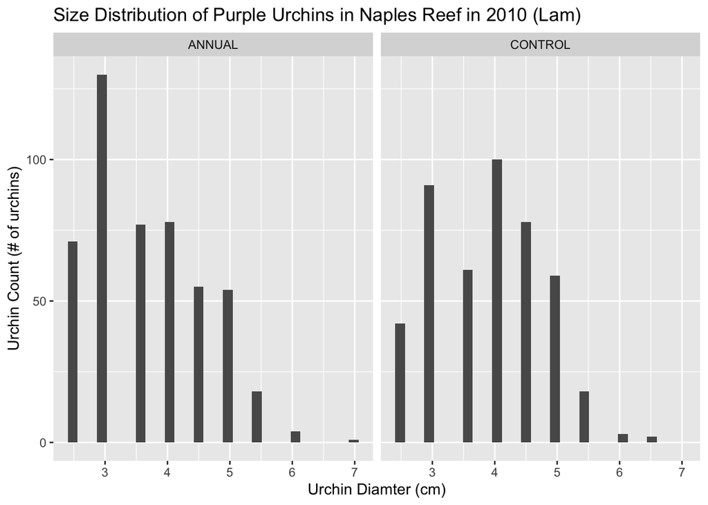

```r
ggplot(data = purp_naples_2010, aes(x = size)) +
  geom_histogram() +
  facet_wrap(~ treatment) +
  labs(x = "Urchin Diamter (cm)",
       y = "Urchin Count (# of urchins)",
       title = "Size Distribution of Purple Urchins in Naples Reef in 2010 (Lam)")
```

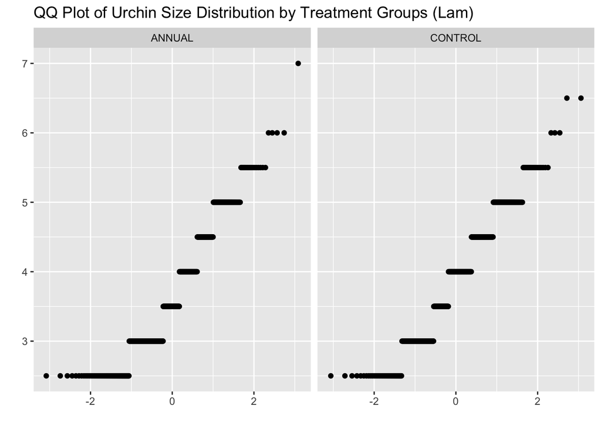

```r
ggplot(data = purp_naples_2010, aes(sample = size)) +
  geom_qq() +
  facet_wrap(~ treatment) +
  labs(x = "",
       y = "",
       title = "QQ Plot of Urchin Size Distribution by Treatment Groups (Lam)")
```

The distribution of purple urchin sizes for each treatment in Naples Reef from 2010 appears fairly normal. Both treatments appear to have a slight positive skew, but the annual treatment’s skew seems slightly more dramatic than that of the control treatment. However, when coupled with the relatively linear QQ plot, it seems plausible that out sample came from a population with normal distribution and therefore we can treat this data as normal for further statistical analysis.